# Web Traffic Time Series Forecasting

Aakash Pahuja

27th Nov 2020

### Overview

#### Description

We decided to work on one of the most burning time series problem of today’s day and era, “predicting web traffic”. We believe that this forecasting can help website servers a great deal in effectively handling outages. The technique we implemented can be extended to diverse applications in financial markets, weather forecasts, audio and video processing. Not just that, understanding your website’s traffic trajectory can open up business opportunities too.

#### Dataset

The dataset consists of 145k time series representing the number of daily page views of different Wikipedia articles, starting from July 1st, 2015 up until September 10th, 2017 (804 data points).

#### For these models, I have focused on the **3C_zh** wikipedia page

```r
# basic imports
library("fpp")
library("ggplot2")
library("xts")
```

#### Importing the data

```r
train_1 <- read.csv("train_1.csv", header = TRUE, row.names = 1,sep = ",",skip =0)
website <- data.matrix(train_1[c("3C_zh.wikipedia.org_all-access_spider"),])
```

### ARIMA model

#### Preparing data to make it ready for time-series

```r
# removing column names
dimnames(website) <- NULL
# converting to array
website <- array(website)
# checking the values
head(website)
```

```
## [1] 1 0 1 1 0 4
```

```r
# no. of ovservations
length(website)
```

```
## [1] 550
```

So, we see that there are 550 observations, i.e. number of views for the wikipedia page for 550 days from 1st July 2015 till 31st Dec 2016

Let’s convert it to time-series and then split it to train and test - we will train our models for the period 1st July 2015 till 20th Dec 2016 and we will forecast for 21st Dec 2016 to 31st Dec 2016

```r
# converting to time-series
time_index <- seq(from = as.POSIXct("2015-07-01"),to = as.POSIXct("2016-12-31"), by = "day")
website_ts <- xts(website, order.by =time_index ,frequency = 365.25)
# checking first few values
head(website_ts)
```

```
##            [,1]
## 2015-07-01    1
## 2015-07-02    0
## 2015-07-03    1
## 2015-07-04    1
## 2015-07-05    0
## 2015-07-06    4
```

```r
# splitting to train and test
website_ts_train <- website_ts['2015-07-01/2016-12-20']
website_ts_test <- website_ts['2016-12-21/2016-12-31']
```

Now, let’s look at our train data.

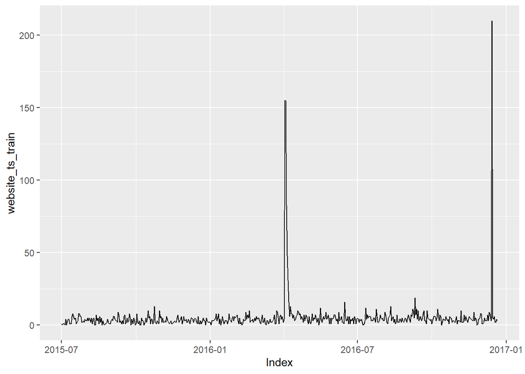

```r
autoplot(website_ts_train,xlab = "Time")
```

```r
# replacing the outlier with mean
website_ts_train[website_ts_train>100]
```

```
##                     [,1]
## 2016-04-02 00:00:00  155
## 2016-04-03 00:00:00  155
## 2016-12-13 23:00:00  210
```

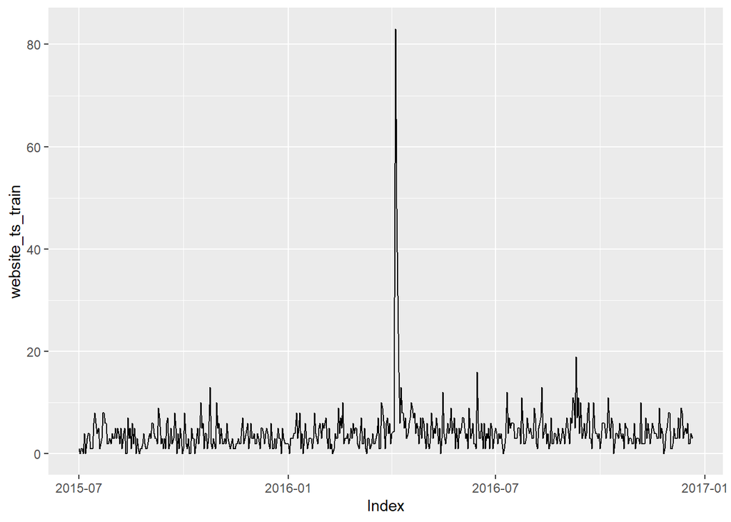

```r
website_ts_train[website_ts_train>100] <- mean(website_ts_train[!website_ts_train>=100])
# plotting
autoplot(website_ts_train)
```

We can still see an outlier around 2016-04, lets remove that too

```r
website_ts_train[website_ts_train>20]
```

```
##            [,1]
## 2016-04-04   83
## 2016-04-05   48
## 2016-04-06   31
```

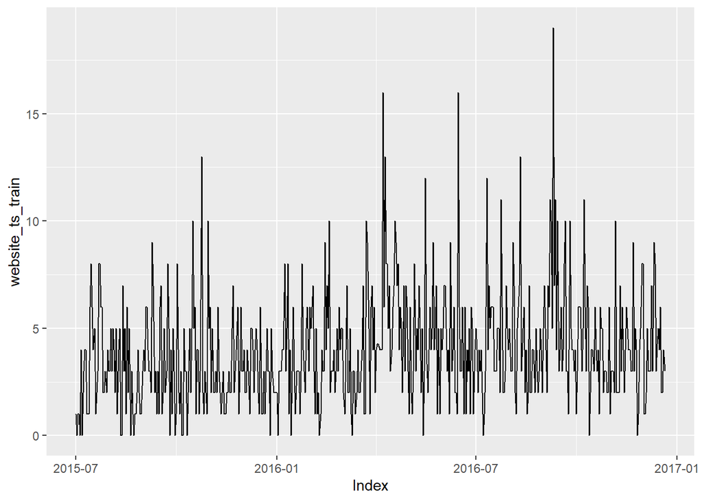

```r
website_ts_train[website_ts_train>20] <- mean(website_ts_train[!website_ts_train>20])
# plotting
autoplot(website_ts_train)
```

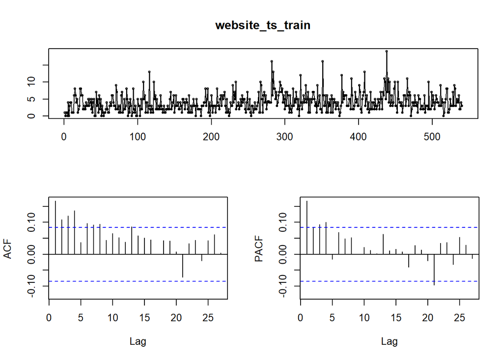

```r
tsdisplay(website_ts_train)
```

Looks much better now. But we may notice that the variance is increasing over time, so transformation of data might be needed to de-couple variance from the mean, but lets confirm that with the BoxCox function

Transforming the data –>

```r
# finding ideal lambda
BoxCox.lambda(website_ts_train)
```

```
## [1] 0.357943
```

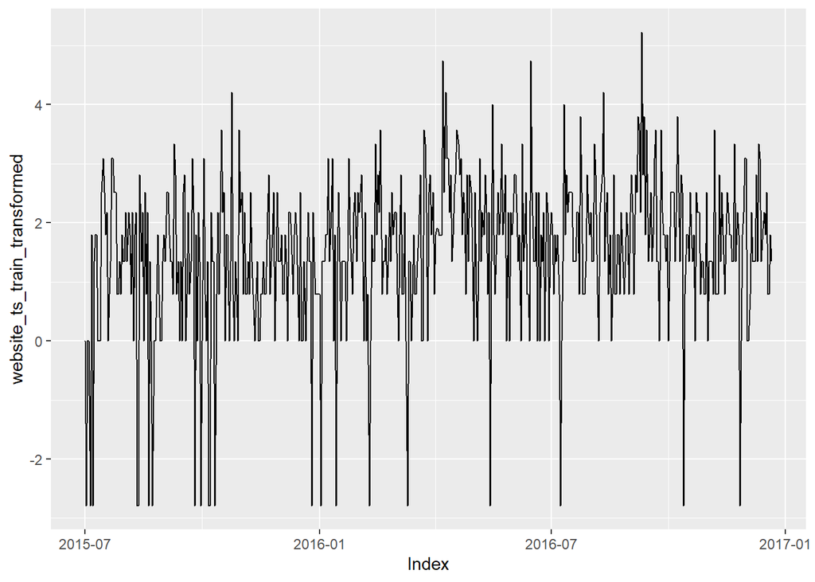

```r
# transforming the data
website_ts_train_transformed <- BoxCox(website_ts_train,lambda = 0.357943)
# visualizing again
autoplot(website_ts_train_transformed)
```

Few things we can notice about the time-series ->

1. It has a slight non-seasonal and long-term trend
2. Might be a hint of cyclical component
3. The level does not seem constant over time

Now, let’s look at the ACF and PACF for this time-series

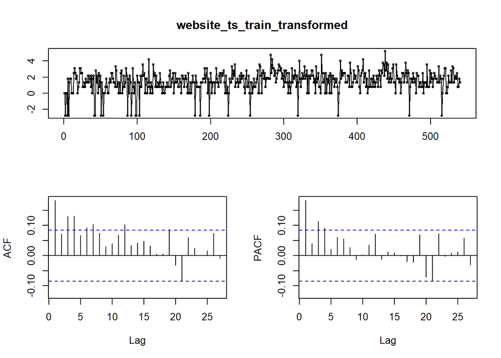

```r
tsdisplay(website_ts_train_transformed)
```

From the ACF/PACF we can see –>

1. Most of the lines in the ACF are within the boundary, which shows that our data is white noise, hence this indicates that the data is **stationary**.
2. Drop in PACF after lag 1, this might be an indication that we can apply AR model with order = 1

Applying KPSS test to check stationarity –>

```r
kpss.test(website_ts_train_transformed)
```

```
##
##  KPSS Test for Level Stationarity
##
## data:  website_ts_train_transformed
## KPSS Level = 1.7632, Truncation lag parameter = 6, p-value = 0.01
```

The p-value = 0.01  
=> We reject the NULL hypothesis  
=> The data is **NOT stationary**

So, to handle the non-seasonal non-stationarity, let’s apply 1 order of non-seasonal differencing.

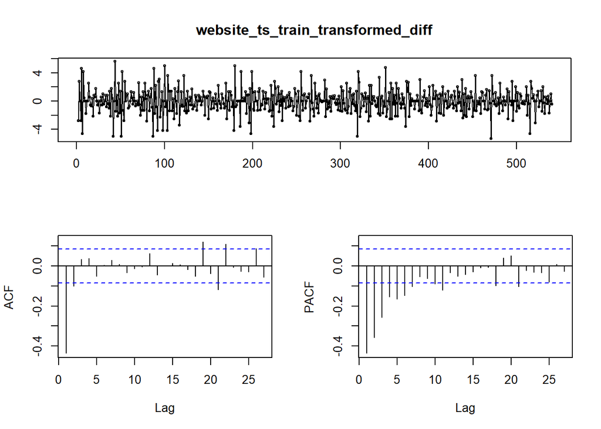

```r
# applying 1st order differencing
website_ts_train_transformed_diff <- diff(website_ts_train_transformed)
# visualizing data
tsdisplay(website_ts_train_transformed_diff)
```

Now, we can see from time-series plot the data appears stationary. From the ACF, we can see that there is no more slow decay, which indicates it **is stationary**.

Let’s confirm this with KPSS test

```r
kpss.test(website_ts_train_transformed_diff)
```

```
##
##  KPSS Test for Level Stationarity
##
## data:  website_ts_train_transformed_diff
## KPSS Level = 0.0099393, Truncation lag parameter = 6, p-value = 0.1
```

Here, p-value = 0.1  
=> The data **is stationary**

Applying auto.arima

```r
auto.arima(website_ts_train,seasonal = TRUE,lambda = 0.357943)
```

```
## Series: website_ts_train
## ARIMA(0,1,2)
## Box Cox transformation: lambda= 0.357943
##
## Coefficients:
##           ma1      ma2
##       -0.8489  -0.1252
## s.e.   0.0432   0.0434
##
## sigma^2 estimated as 1.609:  log likelihood=-893.48
## AIC=1792.96   AICc=1793.01   BIC=1805.83
```

The auto.arima also chooses the value for d as 1, so lets go ahead and create the ARIMA model.

Applying the model suggested by auto.arima

```r
m1 <-Arima(website_ts_train,order=c(0,1,2),include.drift = TRUE, lambda = 0.357943)
m1
```

```
## Series: website_ts_train
## ARIMA(0,1,2) with drift
## Box Cox transformation: lambda= 0.357943
##
## Coefficients:
##           ma1      ma2   drift
##       -0.8538  -0.1317  0.0017
## s.e.   0.0430   0.0437  0.0009
##
## sigma^2 estimated as 1.606:  log likelihood=-892.63
## AIC=1793.26   AICc=1793.33   BIC=1810.42
```

Forecasting

```r
forecast(m1,h=10)
```

```
##          Point Forecast    Lo 80    Hi 80     Lo 95    Hi 95
## 46656001       3.930390 1.148931 9.205315 0.4365043 13.24232
## 46742401       4.096045 1.205137 9.563783 0.4613101 13.74346
## 46828801       4.100296 1.206885 9.571828 0.4621996 13.75410
## 46915201       4.104550 1.208635 9.579877 0.4630901 13.76474
## 47001601       4.108806 1.210386 9.587931 0.4639818 13.77538
## 47088001       4.113066 1.212139 9.595989 0.4648747 13.78603
## 47174401       4.117328 1.213894 9.604051 0.4657686 13.79668
## 47260801       4.121593 1.215650 9.612117 0.4666637 13.80734
## 47347201       4.125861 1.217408 9.620188 0.4675598 13.81801
## 47433601       4.130132 1.219168 9.628263 0.4684571 13.82868
```

Visualizing the forecast

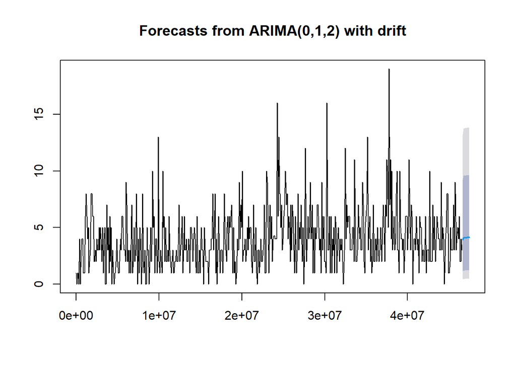

```r
plot(forecast(m1,h=10))
```

Checking model performance

```r
accuracy(forecast(m1,h=10),website_ts_test)
```

```
##                     ME     RMSE      MAE       MPE     MAPE      MASE
## Training set 0.6622989 2.675221 1.948219      -Inf      Inf 0.4882358
## Test set     0.9051931 4.460078 2.624405 -54.82804 84.51735 0.6576920
##                     ACF1
## Training set 0.009676911
## Test set              NA
```

There is someoverfitting, but otherwise the ARIMA model does pretty good. Now let look at the naive models

### Naive Models

```r
Model_Mean <- meanf(website_ts_train, h=10)
Model_Naive <- naive(website_ts_train, h=10)
Model_Drift <- rwf(website_ts_train, h=10, drift=TRUE)
accuracy(Model_Mean,website_ts_test)
```

```
##                         ME     RMSE      MAE       MPE     MAPE    MASE
## Training set -7.829947e-18 2.650704 1.994064      -Inf      Inf 1.00000
## Test set      1.009675e+00 4.496604 2.601935 -51.03436 81.78297 1.30484
```

```r
accuracy(Model_Naive,website_ts_test)
```

```
##                       ME     RMSE      MAE       MPE     MAPE      MASE
## Training set 0.003710575 3.422756 2.557617      -Inf      Inf 0.6409546
## Test set     2.000000000 4.816638 2.800000 -13.55042 66.44958 0.7016972
##                    ACF1
## Training set -0.4664996
## Test set             NA
```

```r
accuracy(Model_Drift,website_ts_test)
```

```
##                         ME     RMSE      MAE       MPE     MAPE      MASE
## Training set -1.104074e-16 3.422754 2.558092      -Inf      Inf 0.6410737
## Test set      1.979592e+00 4.802266 2.789981 -14.11912 66.47458 0.6991865
##                    ACF1
## Training set -0.4664996
## Test set             NA
```

So, we see that our model test RMSE is better than that of all naive models.

Let’s see how the residuals are.

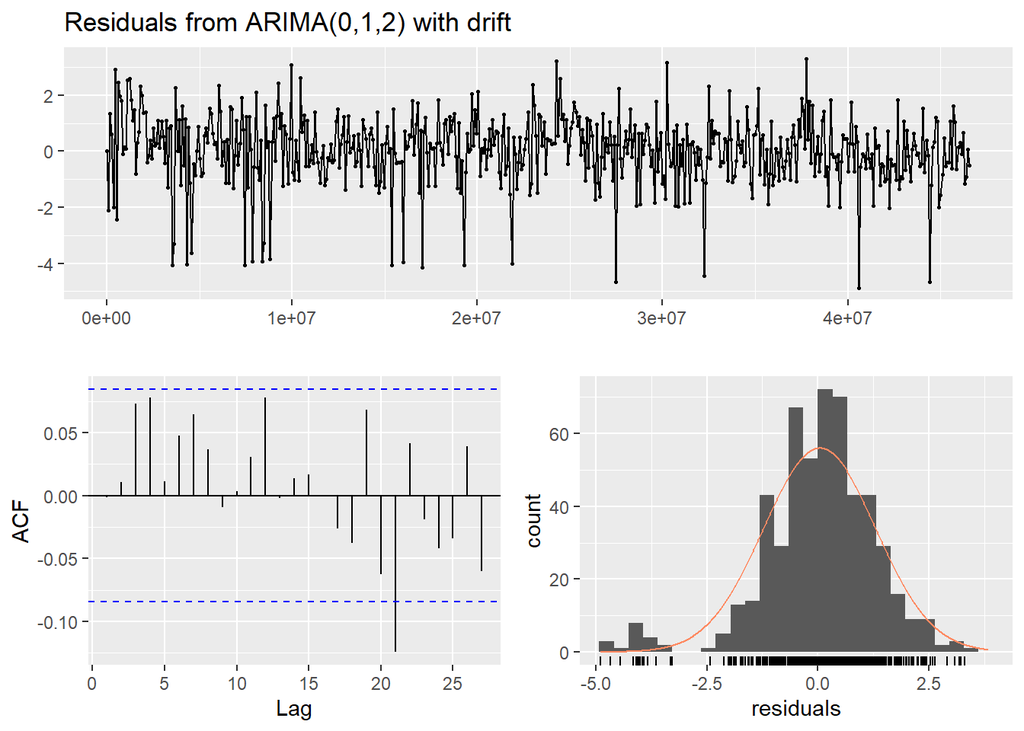

```
##
##  Ljung-Box test
##
## data:  Residuals from ARIMA(0,1,2) with drift
## Q* = 10.722, df = 7, p-value = 0.1512
##
## Model df: 3.   Total lags used: 10
```

```r
checkresiduals(m1)
```

From the time-series of the residuals, we see that its mean = 0 => our model is not biased.

### ETS model

Now, let’s try forecasting with ETS model and see how it turns out.

```r
m2 <- ets(website_ts_train,lambda = "auto")
m2
```

```
## ETS(A,Ad,N)
##
## Call:
##  ets(y = website_ts_train, lambda = "auto")
##
##   Box-Cox transformation: lambda= 0.3579
##
##   Smoothing parameters:
##     alpha = 0.0295
##     beta  = 1e-04
##     phi   = 0.9016
##
##   Initial states:
##     l = -0.7284
##     b = 0.227
##
##   sigma:  1.2695
##
##      AIC     AICc      BIC
## 3662.170 3662.327 3687.919
```

```r
accuracy(forecast(m2,h=10),website_ts_test)
```

```
##                     ME     RMSE      MAE      MPE     MAPE      MASE      ACF1
## Training set 0.6691825 2.677807 1.945668     -Inf      Inf 0.4875963 0.1060352
## Test set     1.3421868 4.582695 2.668392 -38.4473 76.63247 0.6687156        NA
```

The ets function is a function from the R Forecast package which is used to automatically select which one of the possible exponential smoothing models best fits the data. It uses the state space representation to do so, hence we dont need to use **Holt** or **Holt-Winters**, which are both exponential smoothing functions with a trend component.